# Tutorial LIME images and tabular data

```python
labels = {}
for k,v in imagenet_labels.items():
    labels[v[1]] = int(k)
```

```python
inet_model = inc_net.InceptionV3()
```

# Pre-loading images and explainers

```python
explainer = lime_image.LimeImageExplainer()
```

## Black cat/bear

```
('n02133161', 'American_black_bear', 0.63715994)
('n02105056', 'groenendael', 0.031818099)
('n02104365', 'schipperke', 0.029944418)
('n01883070', 'wombat', 0.028509431)
('n01877812', 'wallaby', 0.025093598)
```

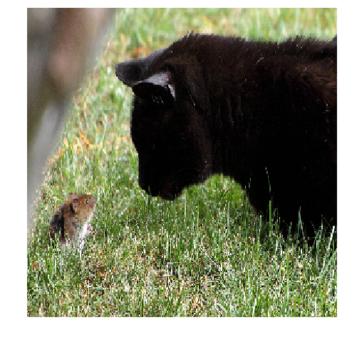

```python
img_catbear = transform_img_fn([os.path.join('data','cat_mouse.jpg')])
# I'm dividing by 2 and adding 0.5 because of how this Inception represents images
_ = plt.imshow(img_catbear[0] / 2 + 0.5)
_ = plt.axis('off')
preds_catbear = inet_model.predict(img_catbear)
for x in decode_predictions(preds_catbear)[0]:
    print(x)
```

```python
explanation_catbear = explainer.explain_instance(img_catbear[0],
                                                 inet_model.predict,
                                                 top_labels=5,
                                                 hide_color=0,
                                                 num_samples=1000)
```

# Puis lancer RISE (bouton Enter/Exit Live Reveal Liveshow).

# Interpretability in three little steps

In only 3 lines, LIME provides a way to explain why a model made a certain prediction!

```
explainer = lime_image.LimeImageExplainer()
```

```
explanation = explainer.explain_instance(images[0], inet_model.predict, top_labels=5, hide_color=0, num_samples=1000)
```

```
temp, mask = explanation_orange.get_image_and_mask(label=labels['orange'], positive_only=True, num_features=5, hide_rest=True)
```

# Google's Inception v3 model

Inception-v3 is trained for the ImageNet Large Visual Recognition Challenge using the data from 2012

[figure not shown]

This is a dataset used for a standard task in computer vision, where models try to classify entire images into 1000 classes, like "Zebra", "Dalmatian", and "Dishwasher".

```python
# Loading the inception model
inet_model = inc_net.InceptionV3()
```

# LIME Image Explainer

```
('n02133161', 'American_black_bear', 0.63715994)
('n02105056', 'groenendael', 0.031818099)
('n02104365', 'schipperke', 0.029944418)
('n01883070', 'wombat', 0.028509431)
('n01877812', 'wallaby', 0.025093598)
```

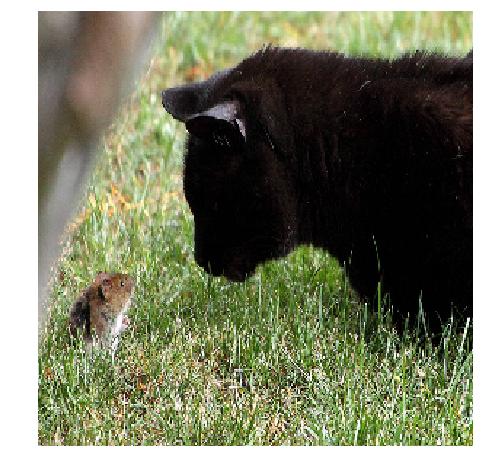

```python
# cat_mouse.jpg
img_catbear = transform_img_fn([os.path.join('data','cat_mouse.jpg')])
# I'm dividing by 2 and adding 0.5 because of how this Inception represents images
_ = plt.imshow(img_catbear[0] / 2 + 0.5)
_ = plt.axis('off')
preds_catbear = inet_model.predict(img_catbear)
for x in decode_predictions(preds_catbear)[0]:
    print(x)
```

**LimeImageExplainer()**:

*Explains predictions on Image (i.e. matrix) data. For numerical features, perturb them by sampling from a Normal(0,1) and doing the inverse operation of mean-centering and scaling, according to the means and stds in the training data. For categorical features, perturb by sampling according to the training distribution, and making a binary feature that is 1 when the value is the same as the instance being explained.*

```python
explainer = lime_image.LimeImageExplainer()
```

```
explanation_catbear = explainer.explain_instance(image=img_catbear[0],
                                                 classifier_fn=inet_model.predict,
                                                 top_labels=5,
                                                 hide_color=0,
                                                 num_samples=1000)
```

# What are the superpixel?

[figure not shown]

**explain_instance()**:

*Generates explanations for a prediction.*

_First, we generate neighborhood data by randomly perturbing features from the instance. We then learn locally weighted linear models on this neighborhood data to explain each of the classes in an interpretable way (see lime*base.py).*

```python
explanation_catbear = explainer.explain_instance(image=img_catbear[0],
                                                 classifier_fn=inet_model.predict,
                                                 top_labels=5,
                                                 hide_color=0,
                                                 num_samples=1000)
```

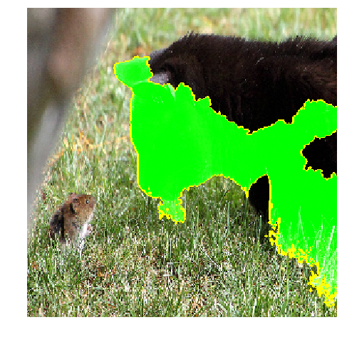

```python
temp, mask = explanation_catbear.get_image_and_mask(label=labels['American_black_bear'],
                                                    positive_only=False,
                                                    num_features=10,
                                                    hide_rest=False,
                                                   min_weight=0.1)
_ = plt.imshow(mark_boundaries(temp / 2 + 0.5, mask))
_ = plt.axis('off')
```

# Loading the preprocessed data

```python
# Load (preprocessed) data
#
# The raw data was downloaded from https://data.stanford.edu/hcmst and preprocessed.
# We combined data sets collected across several years, we transformed select variables
# (e.g., partner_education to be at the same level of granularity as education),
# and added variables like the absolute age difference, education difference, etc.
# Finally, we determined whether couples were still together (i.e., our labels).
#
# We provide the preprocessed data as a csv file in the same repo as this notebook.
```

```python
df = pd.read_csv('data/couples.csv')
```

```python
# Order features (numeric first, categorical second) since it's convenient later
feature_order = ['age',
                 'partner_age',
                 'age_diff_abs',
                 'children',
                 'visits_relatives',
                 'education',
                 'marital_status',
                 'partner_education',
                 'gender',
                 'house',
                 'income',
                 'msa',
                 'rent',
                 'political',
                 'religion',
                 'work',
                 'gender_older',
                 'education_difference',
                 'success']
```

```python
data = df[feature_order]
data = data[data.house != 'boat, rv, van, etc.'] # only one data point with this value, discard
labels = data.pop('success')
```

# Let's have a look at the data

```python
# Take a peak at the data
data.head(3)
```

|  | age | partner_age | age_diff_abs | children | visits_relatives | education | marital_status | partner_education | gender | house | income | msa | rent | political | religion | work | gender_older | education_difference |
| --- | --- | --- | --- | --- | --- | --- | --- | --- | --- | --- | --- | --- | --- | --- | --- | --- | --- | --- |
| 0 | 52 | 48 | 4 | 0.0 | 0 | bachelor's degree or higher | living with partner | some college | female | a building with 2 or more apartments | $20,000 to $24,999 | metro | rented for cash | democrat | catholic | working - as a paid employee | 1 | 1 |
| 1 | 28 | 30 | 2 | 0.0 | 0 | bachelor's degree or higher | living with partner | bachelor's degree or higher | female | a building with 2 or more apartments | $40,000 to $49,999 | metro | rented for cash | democrat | jewish | working - as a paid employee | 0 | 0 |
| 2 | 31 | 40 | 9 | 0.0 | 1 | some college | never married | high school | male | a building with 2 or more apartments | $40,000 to $49,999 | metro | owned or being bought by you or someone in you... | democrat | other non-christian, please specify: | working - as a paid employee | 1 | 1 |

```python
# Define categorical names and indices
categorical_features = list(data.columns[5:])
categorical_idx = list(range(5, len(data.columns)))
continuous_features = list(data.columns[0:5])
continuous_idx = list(range(0,5))

X = data.values

# Get feature names and their values for categorical data (needed for LIME)
categorical_names = {}
for idx, feature in zip(categorical_idx, categorical_features):
    le = LabelEncoder()
    X[:, idx] = le.fit_transform(X[:, idx])
    categorical_names[idx] = le.classes_

# To suppress a warning later (not strictly necessary)
X = X.astype(float)

# Train test split
train, test, labels_train, labels_test = train_test_split(
    X, labels, train_size=0.70, random_state=42
)
```

```python
# Preprocessing pipeline
#
# LIME needs a function that takes raw inputs and returns a prediction (see below).
# We use sklearn's pipeline to handle preprocessing, it simplifies the interaction with LIME (see below).
# There are several ways to build this pipeline. For demo purposes, we here show the verbose option (and we
# avoid scaling one-hot encoded features).

continuous_pipeline = Pipeline([
    ('selector', DataSelector(continuous_idx)),
    ('scaler', StandardScaler()),
    ])

categorical_pipeline = Pipeline([
    ('selector', DataSelector(categorical_idx)),
    ('encoder', OneHotEncoder(sparse=False)),
    ])

preprocessing_pipeline = FeatureUnion(transformer_list=[
    ("continuous_pipeline", continuous_pipeline),
    ("categorical_pipeline", categorical_pipeline),
    ])

# There are less verbose alternatives, especially if we scale one-hot encoded features,
# an accepted practice in the machine learning community:
#
#     preprocessing_pipeline = Pipeline([
#        ('onehotencoder', OneHotEncoder(categorical_features=categorical_idx, sparse=False)),
#        ('scaler', StandardScaler())
#     ])
#
# Finally, instead of the low-level Pipeline constructor, we can use sklearn's makepipeline:
#
#     preprocessing_pipeline = make_pipeline(
#         OneHotEncoder(categorical_features=categorical_idx, sparse=False),
#         StandardScaler()
#     )
```

```python
# Set up the model and GridSearch for random forest hyperparameter tuning
param_grid = [{'n_estimators': [16, 20, 24],
               'max_features': [4, 8, 12, 16],
               'min_samples_split': [8, 12, 16],
               'max_depth': [15, 20, 25]}]

rf = RandomForestClassifier(class_weight='balanced')
grid_search = GridSearchCV(rf, param_grid, cv=5, scoring='neg_mean_squared_error')

# Extend the preprocessing pipeline to include random forest and grid search
pipeline = make_pipeline(preprocessing_pipeline, grid_search)
```

```python
# Fit the model and tune the hyperparameters
pipeline.fit(train, labels_train)
```

```
Pipeline(steps=[('featureunion', FeatureUnion(n_jobs=1,
       transformer_list=[('continuous_pipeline', Pipeline(steps=[('selector', DataSelector(attribute_indices=[0, 1, 2, 3, 4])), ('scaler', StandardScaler(copy=True, with_mean=True, with_std=True))])), ('categorical_pipeline', Pipeline(steps=[('selector'...*n_jobs', refit=True, return_train_score=Tru…
       scoring='neg_mean_squared_error', verbose=0))])
```

```python
# Hyperparameters found by GridSearchCV
print(pipeline.named_steps['gridsearchcv'].best_params_)
```

```
{'max_depth': 25, 'max_features': 16, 'min_samples_split': 8, 'n_estimators': 20}
```

```python
# Evalute random forest classifier on training data (it overfits, small sample size)
y_predict = pipeline.predict(train)
f1 = f1_score(labels_train, y_predict)
print('F1 on train:', f1)
```

```
F1 on train: 0.967495219885
```

```python
# Evalute random forest classifier on test data
y_predict = pipeline.predict(test)
f1 = f1_score(labels_test, y_predict)
print('F1 on test:', f1)
```

```
F1 on test: 0.883720930233
```

# Global interpretability

```python
# Get feature importances of random forest model ("global interpretability")
best_estimator = pipeline.named_steps['gridsearchcv'].best_estimator_

importances = best_estimator.feature_importances_
std = np.std([tree.feature_importances_ for tree in best_estimator.estimators_],
             axis=0)
indices = np.argsort(importances)[::-1]

print("Feature ranking:")
feature_names = data.columns
for f in range(data.shape[1]):
    print("%2d. feature %s (%f)" %
          (f + 1, feature_names[f], importances[indices[f]]))
```

```
Feature ranking:
 1. feature age (0.251522)
 2. feature partner_age (0.079410)
 3. feature age_diff_abs (0.077723)
 4. feature children (0.062838)
 5. feature visits_relatives (0.050203)
 6. feature education (0.044833)
 7. feature marital_status (0.034652)
 8. feature partner_education (0.031375)
 9. feature gender (0.014136)
10. feature house (0.013323)
11. feature income (0.011890)
12. feature msa (0.011735)
13. feature rent (0.011631)
14. feature political (0.010322)
15. feature religion (0.010209)
16. feature work (0.009608)
17. feature gender_older (0.009467)
18. feature education_difference (0.009365)
```

# Local interpretability

```python
# Use LIME to explain individual predictions, initialize explainer object
explainer = LimeTabularExplainer(
    train,
    class_names=['BrokeUp', 'StayedTogether'],
    feature_names=list(data.columns),
    categorical_features=categorical_idx,
    categorical_names=categorical_names,
    discretize_continuous=True
)
```

```
Couples probability of staying together: 0.861681535196
```

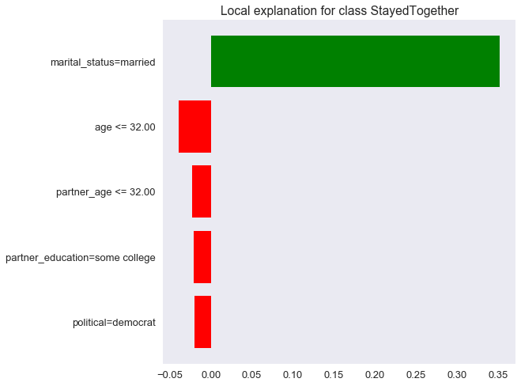

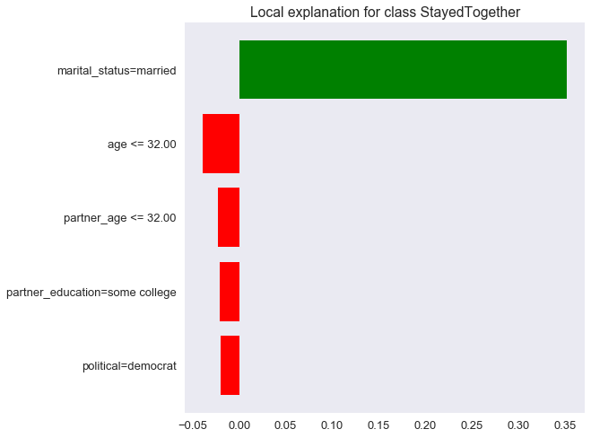

```python
# Explain a prediction ("local interpretability"):
# Now we see that the pipeline that takes raw data and returns the prediction
# of the trained model now comes in conveniently.
example = 3
exp = explainer.explain_instance(test[example], pipeline.predict_proba, num_features=5)
print('Couples probability of staying together:', exp.predict_proba[1])
exp.as_pyplot_figure()
```

```
Couples probability of staying together: 0.765070704778
```

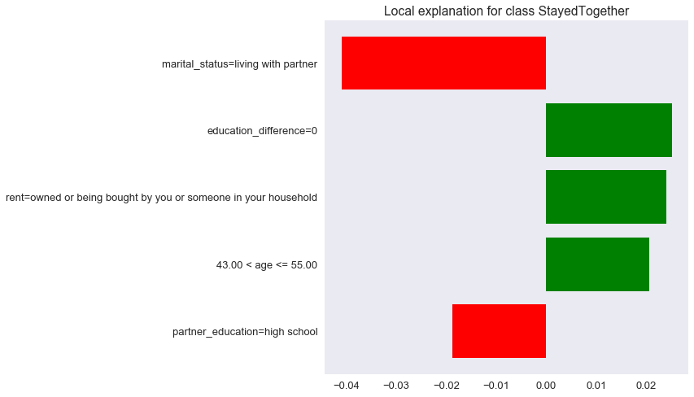

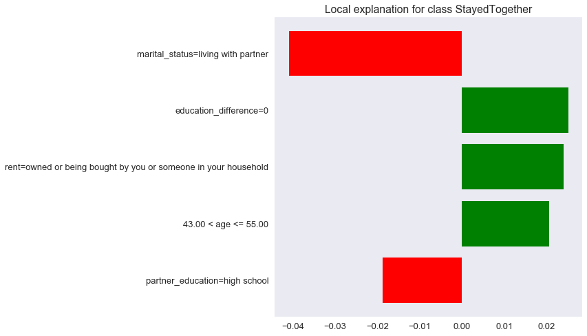

```python
# Explain another prediction ("local interpretability"):
example = 13
exp = explainer.explain_instance(test[example], pipeline.predict_proba, num_features=5)
print('Couples probability of staying together:', exp.predict_proba[1])
exp.as_pyplot_figure()
```

# Wrapping up

In only 3 lines, LIME provides a way to explain why a model made a certain prediction!

```
explainer = lime_image.LimeImageExplainer()

explanation = explainer.explain_instance(images[0], inet_model.predict, top_labels=5, hide_color=0, num_samples=1000)

temp, mask = explanation_orange.get_image_and_mask(label=labels['orange'], positive_only=True, num_features=5, hide_rest=True)
```

```
_ = plt.imshow(mark_boundaries(temp / 2 + 0.5, mask))
_ = plt.axis('off')
```

# Wrapping up

- Work for classification (and regression now)
- It approximates explanation
- However explanation is **not** the global model!

It allows you to train a model in any way you like and still have an answer to the local question, “Why has this particular decision been made?”

What’s more, LIME picks up on patterns in the data learned by the model, it does not inform about reality. Data reflects current and past conventions and social practices (which we see in our results). LIME is no oracle, but it allows humans to enter a more collaborative relationship with black-box machine learning models, and question them when necessary.